# Elecciones presidenciales 2021

Análisis de participación electoral

Pablo Javier Aguirre Hörmann

# Cargar paquetes

```r
library(readr) # Cargar datos
library(dplyr) # Manejo de datos
library(ggplot2) # Visualización de datos
library(stargazer) # Reportar tabla de regresión
library(chilemapas) # Mapas de Chile
```

# Datos a utilizar

Usaremos el archivo `BBDDComuna.csv` el cual se construyó con datos tanto del SERVEL como del Ministerio de Desarrollo Social (ver script `0.CrearDatosEleccionesPresidente2021.R` en la carpeta `datos`).

```r
datos_votaciones_pob <- read_csv("../0.datos/BBDDComuna.csv")
glimpse(datos_votaciones_pob)
```

```
## Rows: 346
## Columns: 15
## $ region        <chr> "DE VALPARAISO", "METROPOLITANA DE SANTIAGO", "DEL BIOBI~
## $ orden_reg     <dbl> 6, 7, 11, 4, 2, 14, 5, 12, 16, 3, 11, 11, 1, 15, 7, 10, ~
## $ distrito      <chr> "DISTRITO 7", "DISTRITO 14", "DISTRITO 21", "DISTRITO 4"~
## $ com_nom       <chr> "ALGARROBO", "ALHUE", "ALTO BIOBIO", "ALTO DEL CARMEN", ~
## $ cod_servel    <dbl> 2564, 2801, 2674, 2523, 2502, 2717, 2528, 2696, 2752, 25~
## $ cod_casen     <dbl> 5602, 13502, 8314, 3302, 1107, 10202, 4103, 9201, NA, 21~
## $ padron        <dbl> 14805, 6118, 5583, 5148, 60343, 38912, 11278, 46976, 233~
## $ vot_boric     <dbl> 4580, 1952, 1283, 1236, 11971, 10412, 4274, 7931, 7, 807~
## $ vot_kast      <dbl> 5096, 1092, 1069, 701, 11897, 8225, 1480, 16634, 26, 529~
## $ vot_nulo      <dbl> 61, 9, 48, 23, 279, 118, 61, 181, 0, 1392, 28, 171, 804,~
## $ vot_blanco    <dbl> 23, 9, 20, 5, 64, 48, 18, 62, 0, 388, 7, 51, 247, 38, 10~
## $ vot_validos   <dbl> 9676, 3044, 2352, 1937, 23868, 18637, 5754, 24565, 33, 1~
## $ vot_tot       <dbl> 9760, 3062, 2420, 1965, 24211, 18803, 5833, 24808, 33, 1~
## $ participacion <dbl> 0.6592367, 0.5004904, 0.4334587, 0.3817016, 0.4012230, 0~
## $ per_pob2020   <dbl> 0.09647624, 0.07195676, 0.28927098, 0.12771383, 0.160921~
```

Esta base de datos tiene información **desagregada a nivel de comuna** para la votación de segunda vuelta de presidentes de Chile que se realizó el mes de diciembre. Se incluye también información a nivel de comuna sobre el total del padrón y el nivel de pobreza (ingresos).

# Distribución en la participación electoral

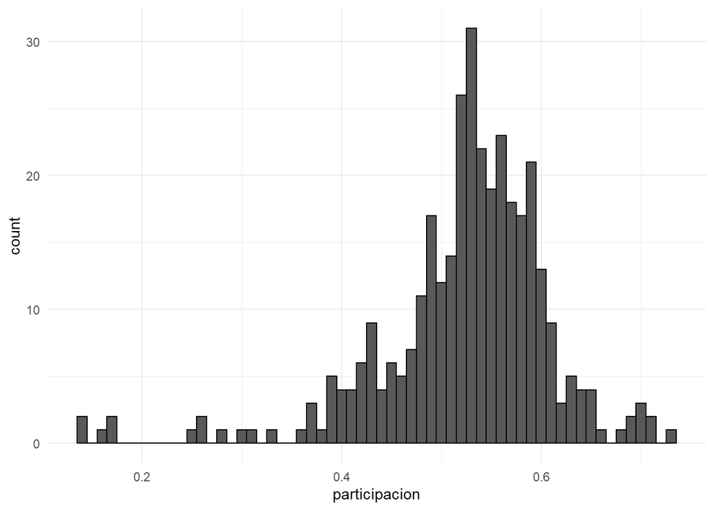

```r
datos_votaciones_pob %>%
  ggplot(aes(x = participacion)) +
  geom_histogram(binwidth = 0.01, col = "black") +
  theme_minimal()
```

El siguiente `boxplot` muestra como se distribuyen los niveles de participación a nivel de comuna para cada región del país.

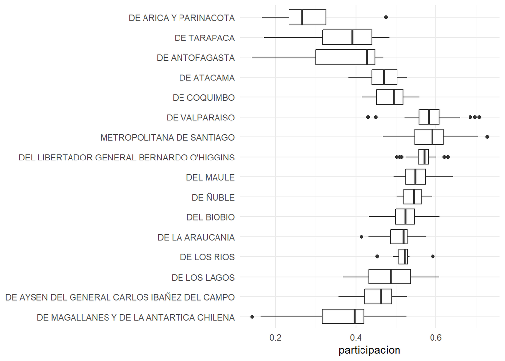

```r
datos_votaciones_pob %>%
  ggplot(aes(y = reorder(region, -orden_reg), x = participacion)) +
  geom_boxplot() +
  theme_minimal() +
  labs(y = NULL)
```

A continuación se muestra la comuna con más y menos participación en la elección.

```r
datos_votaciones_pob %>%
  arrange(-participacion) %>%
  slice(c(1,346)) %>%
  select(region, com_nom, participacion)
```

```
## # A tibble: 2 x 3
##   region                    com_nom  participacion
##   <chr>                     <chr>            <dbl>
## 1 METROPOLITANA DE SANTIAGO VITACURA         0.728
## 2 DE ANTOFAGASTA            OLLAGUE          0.141
```

# Distribución en la pobreza (ingresos)

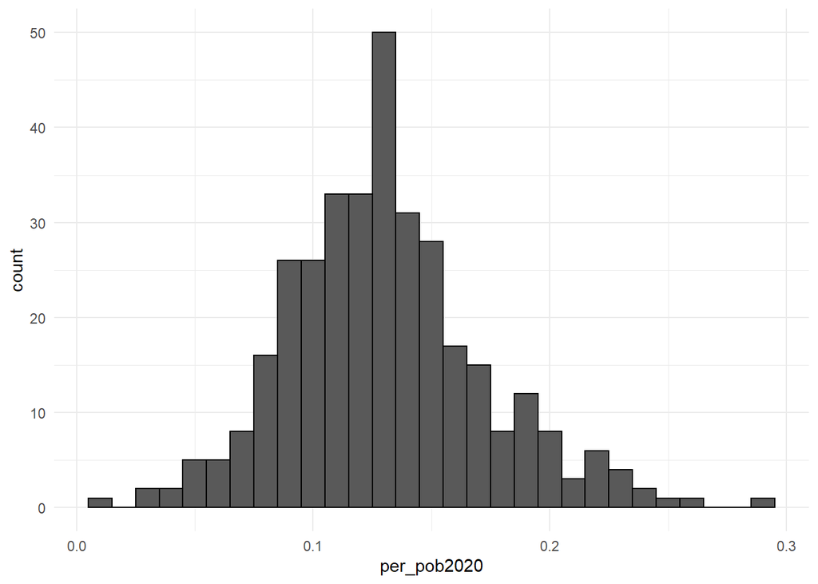

```r
datos_votaciones_pob %>%
  ggplot(aes(x = per_pob2020)) +
  geom_histogram(binwidth = 0.01, col = "black") +
  theme_minimal()
```

El siguiente `boxplot` muestra como se distribuyen los niveles de pobreza a nivel de comuna para cada región del país.

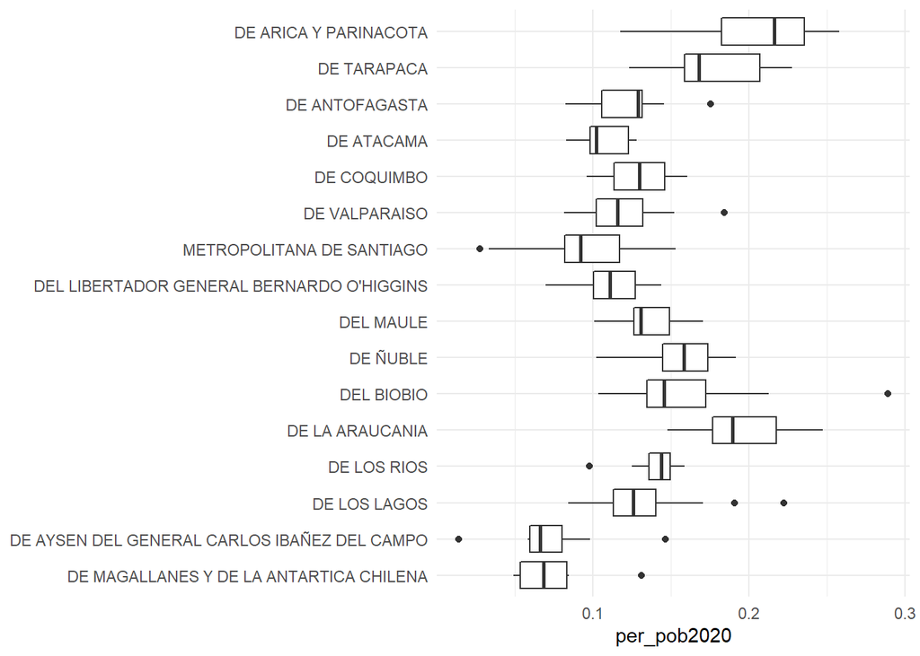

```r
datos_votaciones_pob %>%
  ggplot(aes(y = reorder(region, -orden_reg), x = per_pob2020)) +
  geom_boxplot() +
  theme_minimal() +
  labs(y = NULL)
```

A continuación se muestra la comuna con más y menos niveles de pobreza por ingreso.

```r
datos_votaciones_pob %>%
  filter(!is.na(per_pob2020)) %>%
  arrange(per_pob2020) %>%
  slice(c(1,344)) %>%
  select(region, com_nom, per_pob2020)
```

```
## # A tibble: 2 x 3
##   region                                       com_nom     per_pob2020
##   <chr>                                        <chr>             <dbl>
## 1 DE AYSEN DEL GENERAL CARLOS IBAÑEZ DEL CAMPO O'HIGGINS        0.0141
## 2 DEL BIOBIO                                   ALTO BIOBIO      0.289
```

# Relación entre participación y pobreza

Haremos un primer gráfico entre el nivel de pobreza (`per_pob2020`) y la participación electoral (`participación`).

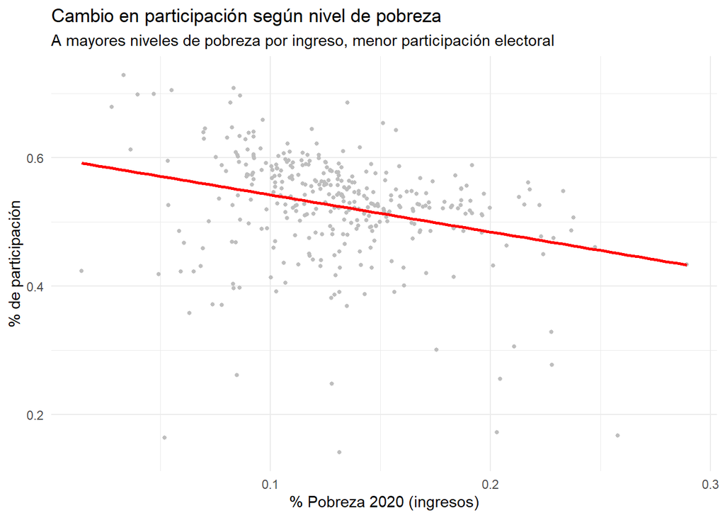

```r
datos_votaciones_pob %>%
  ggplot(aes(x = per_pob2020, y = participacion)) +
  geom_point(size = 1, col = "grey") +
  geom_smooth(method = "lm", se = FALSE, col = "red") +
  theme_minimal() +
  labs(x = "% Pobreza 2020 (ingresos)",
       y = "% de participación",
       title = "Cambio en participación según nivel de pobreza",
       subtitle = "A mayores niveles de pobreza por ingreso, menor participación electoral")
```

## Una regresión para analizar relación

```r
datos_votaciones_pob %>%
  lm(participacion ~ per_pob2020, data = .) %>%
  stargazer(type = "html", omit.stat = c("adj.rsq", "f", "ser"))
```

|  | *Dependent variable:* |
| --- | --- |
|  | participacion |
| per_pob2020 | -0.577*** |
|  | (0.104) |
| Constant | 0.600*** |
|  | (0.014) |
| Observations | 344 |
| R<sup>2</sup> | 0.082 |
| *Note:* | p<0.1; p<0.05; p<0.01 |

## Cómo varía por región

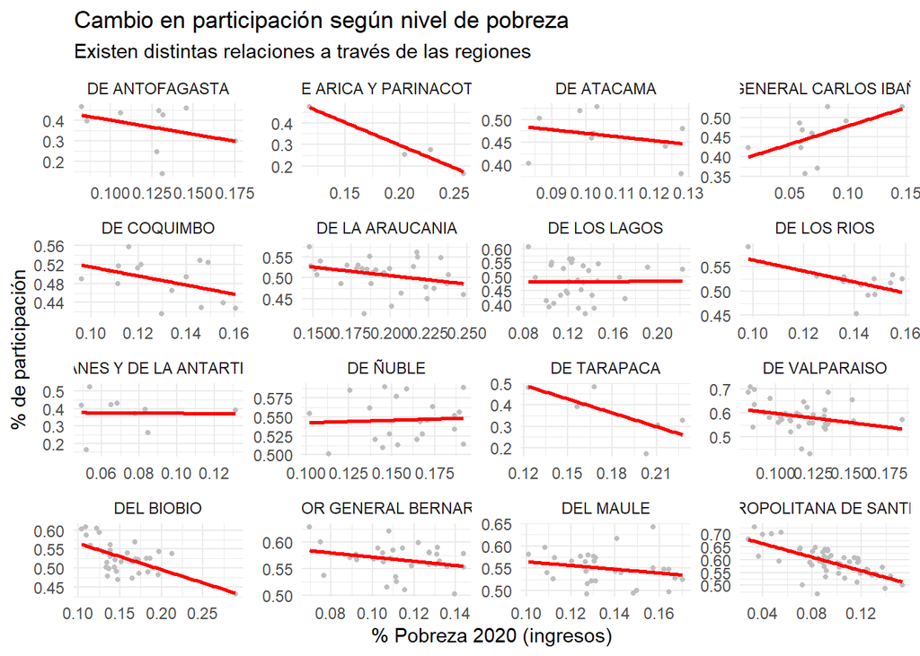

```r
datos_votaciones_pob %>%
  ggplot(aes(x = per_pob2020, y = participacion)) +
  geom_point(size = 1, col = "grey") +
  geom_smooth(method = "lm", se = FALSE, col = "red") +
  theme_minimal() +
  facet_wrap(vars(region), scale = "free") +
  labs(x = "% Pobreza 2020 (ingresos)",
       y = "% de participación",
       title = "Cambio en participación según nivel de pobreza",
       subtitle = "Existen distintas relaciones a través de las regiones")
```

# Mapa

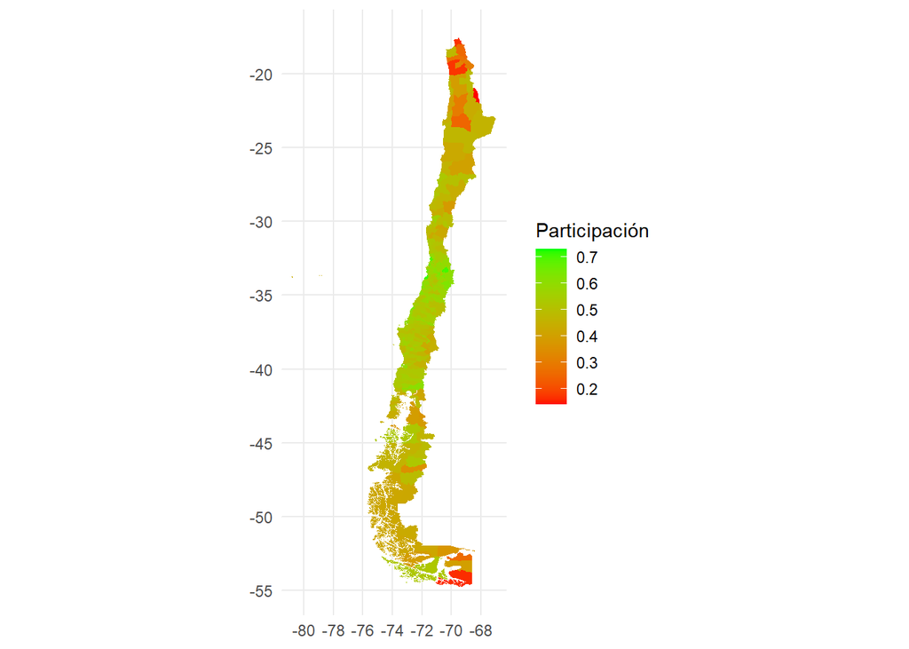

```r
datos_mapa <- mapa_comunas %>%
  mutate(codigo_comuna = as.numeric(codigo_comuna)) %>%
  left_join(datos_votaciones_pob, by = c("codigo_comuna" = "cod_casen")) %>%
  filter(com_nom != "ISLA DE PASCUA")

datos_mapa %>%
  ggplot(aes(geometry = geometry, fill = participacion)) +
  geom_sf(lwd = 0, colour = NA) +
  scale_fill_gradientn(name = "Participación", colours = c("red", "green")) +
  theme_minimal() +
  labs(x = NULL, y = NULL)
```